### *Foreword -- BillyLjm*

Hey, these are my submissions for the **IBM Quantum Challenge, Fall 2020**  
All my solutions are publicly available in my GitHub repo at /BillyLjm/IBMQuantumChallenge2020  
This notebook starts off introducing the problem, but you can jump directly to the solution at Learning Exercise II-A

# Previously on the IBM Quantum Challenge

Ryoko has been stuck in the quantum realm. Please DM Ryoko and ask her about the **quantum realm** and you will find out more.  
She is in a square room with excited qubits blocking her passage.  
How can you help Dr. Ryoko get out of the room?  
You can do this by learning how to solve a famous classic puzzle called "lights out." Good luck!

[<< Click here to communicate with Dr. Ryoko through the web cam >>](https://youtu.be/kLizHnvTguE)

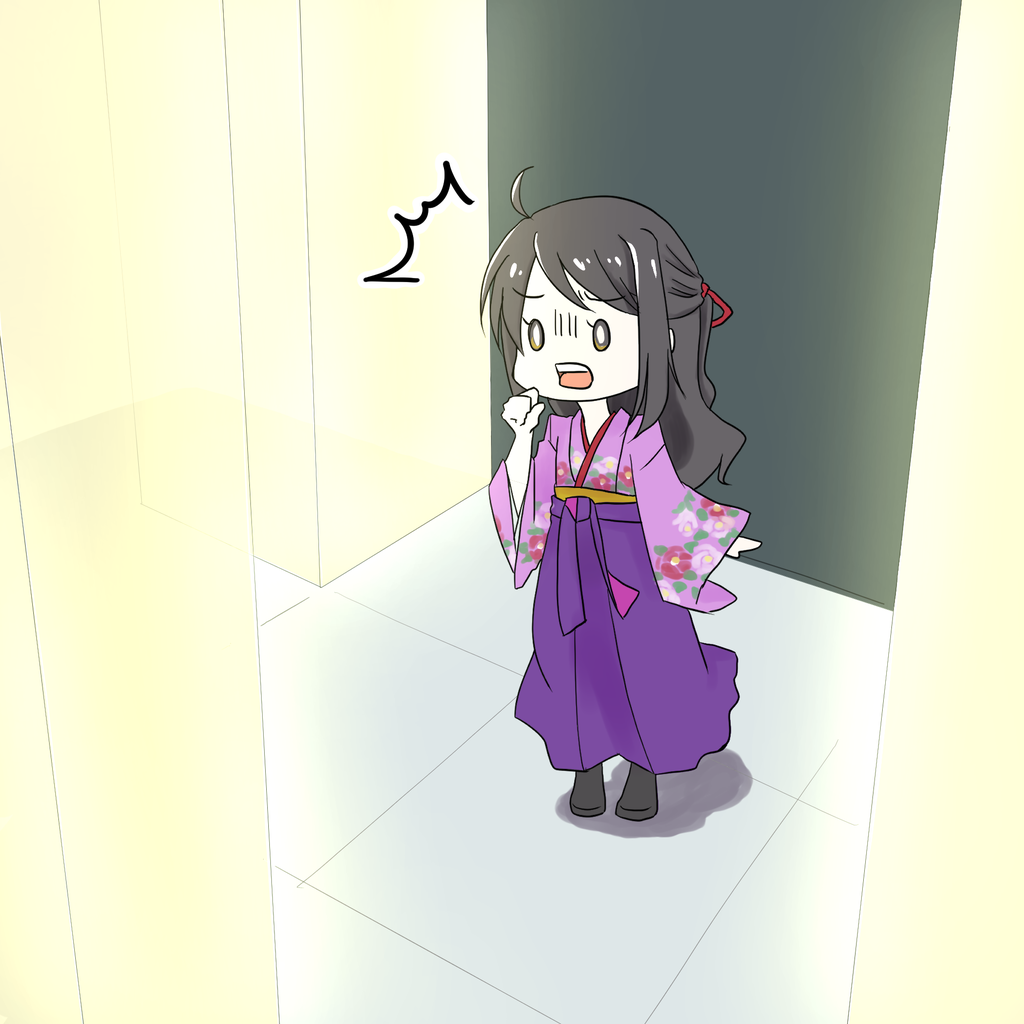

```python
from IPython.display import Image, display
Image('ryoko_pillars.png')
```

# Week2-A: Lights Out Puzzle

**Lights out** is a famous puzzle game. The player is given a rectangular grid of lights which can be switched on and off. When you flip a switch inside one of those squares, it will toggle the on/off state of this and adjacent squares (up, down, left and right). Your goal is to turn all the lights off from a random starting light pattern.

## Example Puzzle

An example of the puzzle with 3 x 3 grid is shown in the figure below. The light squares are labelled from 0 to 8. We can represent the starting pattern using a list of numbers, where `1` represents lights switched on and `0` represnts ligths switched off. The list `lights` below represents the starting pattern in this example (squares 3, 5, 6, 7 are on and the rest are off):

```
lights = [0, 0, 0, 1, 0, 1, 1, 1, 0]
```

The example puzzle can be solved by flipping the switches in square 0, 3 and 4 as illustrated step by step in the figure. If you play with it a little bit, you will soon notice **two important properties of this puzzle game**:

1. You don't need to flip a switch more than once.
2. The order of flipping doesn't matter.

Therefore, we can represent the puzzle solution as a list of numbers similar to the starting pattern. However, the meaning of `0` and `1` are different here: `1` represents flipping a switch and `0` represents *not* flipping a switch.

```
solution = [1, 0, 0, 1, 1, 0, 0, 0, 0]
```

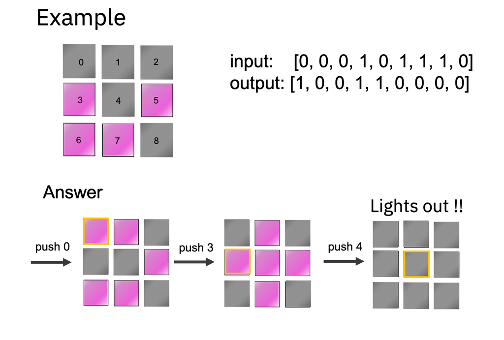

```python
Image('lights_out_rule.png')
```

# Learning Exercise II-A

Let's try to solve a "Lights Out" puzzle using **Grover's algorithm**! The information you learned last week will be helpful in solving this puzzle.

Answer by creating a quantum circuit to solve the puzzle shown in the figure below. In the quantum circuit to be submitted, measure **only the `solution` (9bit)** that solves the puzzle. To submit your solution, create a function which takes `lights` as an input and then returns a `QuantumCircuit`. You can name the function as you like. Make sure it works even with another dataset of "lights". We will validate your circuit with different inputs.

**In addition, please implement the quantum circuit within 28 qubits.**

There are several ways to solve it without using Grover's algorithm, but we ask you to **use Grover's algorithm** for this exercise. It should help you in solving other challenges.

Please note that you can get the answer with the same endian as the one used in the description. You can also use the following function.

```
qc = qc.reverse_bits()
```

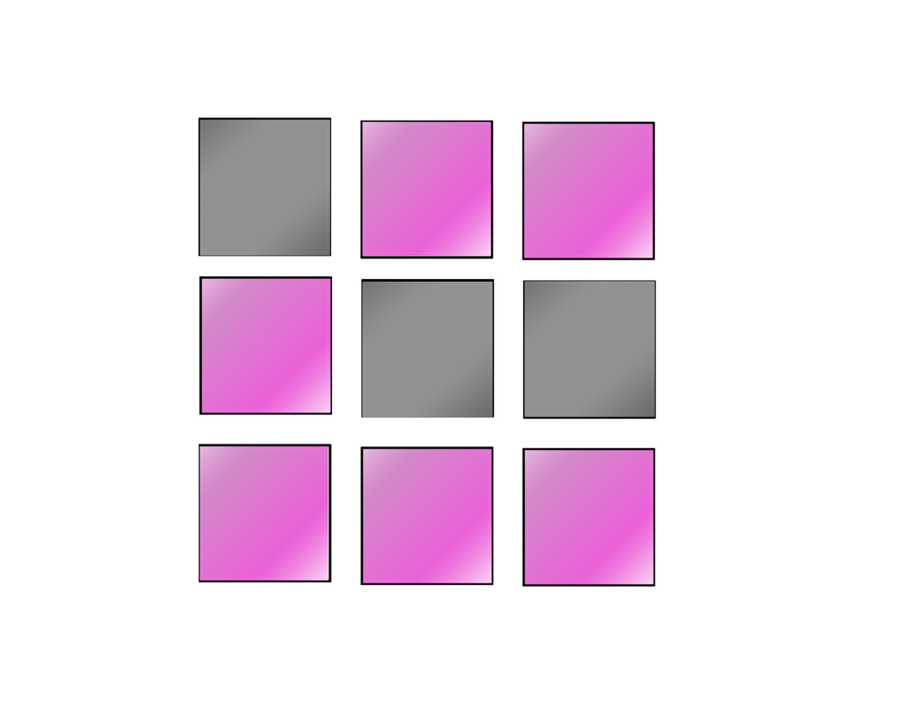

```python
Image('lights_out_prob.png')
```

## Hint

You’ll need a more complex oracle than the “Week1-B oracle” to solve this problem. The added auxiliary qubits will help you design the oracle part, but they need to be handled with care. At the end of the oracle part, all auxiliary qubits must be returned to their initial state (this operation is sometimes called Uncomputation). [Week 3 of last year’s IBM Quantum Challenge](https://github.com/quantum-challenge/2019/blob/master/problems/week3/week3_en.ipynb) will support your understanding of this concept.

If you are not sure about the optimal number of iterations for Grover's algorithm, solve [this quiz](https://github.com/qiskit-community/IBMQuantumChallenge2020/tree/main/quizzes/quiz_1) and talk to Dr. Ryoko(@ryoko) in the Qiskit slack via direct message. You can get important formulas of the theoretical aspects of week 1-B.

```python
from qiskit import QuantumRegister, ClassicalRegister, QuantumCircuit
from qiskit import Aer, execute

from qiskit.transpiler import PassManager
from qiskit.transpiler.passes import Unroller, Optimize1qGatesDecomposition
pass_manager = PassManager(Unroller(['u', 'cx']))

from numpy import pi

# The starting pattern is represented by this list of numbers.
# Please use it as an input for your solution.
lights = [0, 1, 1, 1, 0, 0, 1, 1, 1]
```

```
OrderedDict([('u', 97), ('cx', 42)])
```

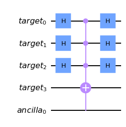

```python
def diffuse(nbits, start='+'):
    """Grover diffusion circuit

    Parameters:
        nbits (int): number of qubits to diffuse
        start (bool): target register intial state. '0' for |0>|0>... (speed: 1 > - > 0 > +)

    Returns:
        QuantumCircuit for (nbits) target qubits, and (nbits-3) ancilla qubits
    """
    # declare quantum circuit
    targets = QuantumRegister(nbits, 'target')
    ancillae = QuantumRegister(nbits-3, 'ancilla') if nbits > 3 else None
    diffuse = QuantumCircuit(targets, name="Diffuse") if ancillae == None \
        else QuantumCircuit(targets, ancillae, name="Diffuse")

    # transfrom state to |11...1->, phase flip, and reverse tranformation
    if nbits == 1:
        qc.z(targets)
    elif start == '1':
        diffuse.h(targets[-1])
        diffuse.mcx(targets[:-1], targets[-1], ancillae, mode='v-chain')
        diffuse.h(targets[-1])
    elif start == '-':
        diffuse.h(targets[:-1])
        diffuse.mcx(targets[:-1], targets[-1], ancillae, mode='v-chain')
        diffuse.h(targets[:-1])
    elif start == '0':
        diffuse.u(pi/2, pi, pi, targets[-1]) # HX gate
        diffuse.x(targets[:-1])
        diffuse.mcx(targets[:-1], targets[-1], ancillae, mode='v-chain')
        diffuse.x(targets[:-1])
        diffuse.u(pi/2, 0, 0, targets[-1]) # XH gate
    elif start == '+':
        diffuse.u(pi/2, 0, 0, targets[:-1]) # XH gate
        diffuse.z(targets[-1])
        diffuse.mcx(targets[:-1], targets[-1], ancillae, mode='v-chain')
        diffuse.z(targets[-1])
        diffuse.u(pi/2, pi, pi, targets[:-1]) # HX gate

    return diffuse

# calculate score contribution
qc = diffuse(9, start="-")
print(pass_manager.run(qc).count_ops())

# draw circuit
qc = diffuse(4, start="-")
qc.draw(output="mpl")
```

```
OrderedDict([('cx', 33)])
```

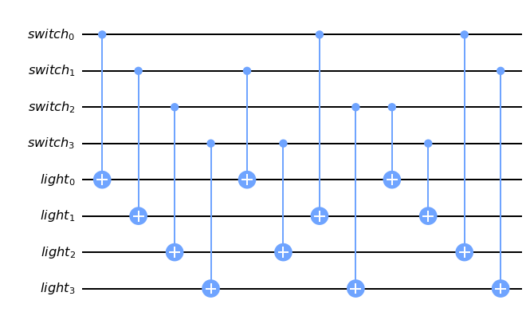

```python
def lightsout(nrows, ncols):
    """Apply lights-out solution
    from a quantum register of switches to flip
    onto a quantum register of lights

    Parameters:
        nrows (int): number of rows in lights-out grid
        ncols (int): number of columns in lights-out grid

    Returns:
        QuantumCircuit for (nrows * ncols) switches qubits,
        and (nrows * ncols) lights qubits
    """
    # declare quantum circuit
    nbits = nrows * ncols
    switches = QuantumRegister(nbits, 'switch')
    lights = QuantumRegister(nbits, 'light')
    lightsout = QuantumCircuit(switches, lights, name="lights out")

    # applies switches to lights
    for i in range(nbits): # flip current tile
        lightsout.cx(switches[i], lights[i])
    for i in range(nbits): # flip left tile
        lightsout.cx(switches[i], lights[i-1]) if i%ncols != 0 else None
    for i in range(nbits): # flip right tile
        lightsout.cx(switches[i], lights[i+1]) if (i%ncols != ncols-1 and i != nbits-1) else None
    for i in range(nbits): # flip top tile
        lightsout.cx(switches[i], lights[i-ncols]) if i >= ncols else None
    for i in range(nbits): # flip bottom tile
        lightsout.cx(switches[i], lights[i+ncols]) if i < nbits-ncols else None

    return lightsout

# calculate score contribution
qc = lightsout(3, 3)
print(pass_manager.run(qc).count_ops())

# draw circuit
qc = lightsout(2, 2)
qc.draw(output="mpl")
```

```
OrderedDict([('cx', 114), ('u', 93)])
```

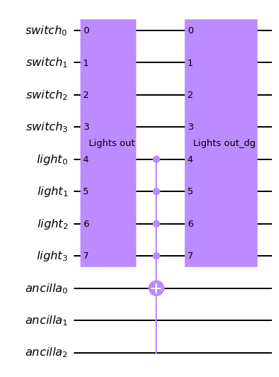

```python
def oracle_lightsout(nrows, ncols, off_val=0, ancillae_init=False):
    """ Grover oracle to check for solution to lights-out puzzle

    Parameters:
        nrows (int): number of rows in lights-out grid
        ncols (int): number of columns in lights-out grid
        off_val (0 or 1): value representing an unlit light (1 is faster)
        ancillae_init (bool): True if ancillae initalised to |-0...0>,
                              False if ancillae intiliased to |00..0>

    Returns:
        QuantumCircuit for (nrows * ncols) switches qubits, (nrows * ncols)
        lights register, and max(nrows * ncols - 1, 1) ancilla qubits
    """
    # declare variables
    nbits = nrows * ncols

    # declare subcircuits
    lo = lightsout(nrows, ncols).to_instruction()

    # declare quantum circit
    switches = QuantumRegister(nbits, 'switch')
    lights = QuantumRegister(nbits, 'light')
    ancillae = QuantumRegister(max(nbits-1, 1), 'ancilla')
    oracle = QuantumCircuit(switches, lights, ancillae, name="oracle_lights")

    # apply switches to lights
    oracle.x(lights) if off_val == 0 else None
    oracle.append(lo, [*switches, *lights])

    # phase flip
    oracle.u(pi/2, pi, pi, ancillae[0]) if not ancillae_init else None # HX gate
    oracle.mcx(lights, ancillae[0], ancillae[1:], mode='v-chain')
    oracle.u(pi/2, 0, 0, ancillae[0]) if not ancillae_init else None # XH gate

    # uncompute lights & ancilla
    oracle.append(lo.inverse(), [*switches, *lights])
    oracle.x(lights) if off_val == 0 else None

    return oracle

# calculate score contribution
qc = oracle_lightsout(3, 3, off_val=1, ancillae_init=True)
print(pass_manager.run(qc).count_ops())

# draw circuit
qc = oracle_lightsout(2, 2, off_val=1, ancillae_init=True)
qc.draw(output="mpl")
```

```
OrderedDict([('cx', 156), ('u', 142), ('measure', 9)])
```

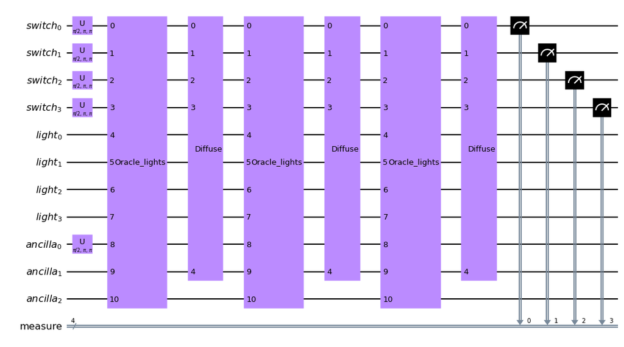

```python
def week2a_ans_func(data, nrows=3, ncols=3, niter=1, grading=True):
    """ Grover search algorithm for lights-out puzzle solution

    Parameters:
        data (list): list indicating which lights are on/off
        nrows (int): number of rows in lights-out grid
        ncols (int): number of columns in lights-out grid
        niter (int): number of iterations of Grover search
        grading (bool): True to reverse-bits & unroll for grading

    Returns:
        QuantumCircuit for (nrows * ncols) switches qubits, (nrows * ncols)
        lights qubits, max(nrows * ncols - 1, 1) ancilla qubits, and
        (nrows * ncols) classical measurement register
    """
    # declare variables
    nbits = nrows * ncols
    assert(nbits == len(data))

    # declare subcircuits
    diff = diffuse(nbits, start="-").to_instruction()
    ora = oracle_lightsout(nrows, ncols, off_val=1, ancillae_init=True).to_instruction()

    # declare quantum circuit
    switches = QuantumRegister(nbits, 'switch') # switches to flip
    lights = QuantumRegister(nbits, 'light') # lights to apply switches on
    ancillae = QuantumRegister(max(nrows * ncols - 1, 1), 'ancilla') # ancilla qubits
    measure = ClassicalRegister(nbits, 'measure') # to measure switches into
    ex2a = QuantumCircuit(switches, lights, ancillae, measure, name='ex2a')

    # initialise qubits
    ex2a.u(pi/2, pi, pi, ancillae[0]) # |->, for oracle only
    ex2a.u(pi/2, pi, pi, switches) # |->, start='-' in diffuse
    for i in range(nbits): # off_val = 1 in oracle
        ex2a.x(lights[i]) if data[i] == 0 else None

    # Grover iteration
    for _ in range(niter):
        ex2a.append(ora, [*switches, *lights, *ancillae])
        ex2a.append(diff, switches) if nbits <= 3 else \
            ex2a.append(diff, [*switches, *ancillae[1:nbits-2]])

    # Output
    ex2a.measure(switches, measure)
    if grading: # optimisation
        ex2a = ex2a.reverse_bits()
        ex2a = PassManager(Unroller(['u', 'cx'])).run(ex2a)
        ex2a = PassManager(Optimize1qGatesDecomposition(['u', 'cx'])).run(ex2a)

    return ex2a

# calculate score contribution
qc = week2a_ans_func(lights, 3, 3, niter=1, grading=True)
print(pass_manager.run(qc).count_ops())

# draw circuit
qc = week2a_ans_func([1,1,1,1], 2, 2, niter=3, grading=False)
qc.draw(output="mpl")
```

The next cell is to find the optimal number of iterations. It takes really long to run

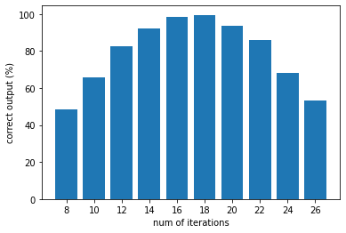

```python
import matplotlib.pyplot as plt
%matplotlib inline

backend = Aer.get_backend('qasm_simulator')
niter = tuple(range(8,27,2))
num_correct = []
shots = 500

for i in niter:
    qc = week2a_ans_func(lights, 3, 3, niter=i)
    job = execute(qc, backend, shots=shots)
    answer = job.result().get_counts()['110010101']
    num_correct.append(answer / shots * 100)

plt.bar(niter, num_correct, width=1.6)
plt.xticks(niter)
plt.xlabel('num of iterations')
plt.ylabel('correct output (%)')
plt.show()
```

Using the minimum iteration number for `week2a_ans_func`, my solution is graded below

```python
# Submission code
from qc_grader import prepare_ex2a, grade_ex2a, submit_ex2a

# Execute your circuit with following prepare_ex2a() function.
# The prepare_ex2a () function works like the execute() function with only QuantumCircuit as an argument.
job = prepare_ex2a(week2a_ans_func)
counts = job.result().get_counts()[0]

# The bit string with the highest number of observations is treated as the solution.
counts_desc = sorted(counts.items(), key = lambda x: x[1], reverse=True)
print(counts_desc[:5])
```

```
Running week2a_ans_func...
Computing cost...
Starting experiments. Please wait...
You may monitor the job (id: 5fc45fc1758a9f0019c42e06) status and proceed to grading when it successfully completes.
[('110010101', 137), ('100010100', 26), ('000010101', 26), ('010001101', 26), ('101111000', 25)]
```

```python
# Check your answer by executing following code.
# The quantum cost of the QuantumCircuit is obtained as the score. The quantum cost is related to rank only in the third week.
grade_ex2a(job)
```

```
Grading your answer. Please wait...

Congratulations 🎉! Your answer is correct.
Your score is 1702.
Feel free to submit your answer.
```

```python
# Submit your results by executing following code. You can submit as many times as you like during the period.
submit_ex2a(job)
```

```
Submitting your answer. Please wait...

Success 🎉! Your answer has been submitted.
```